# Brazilian Aeronautics Accidents

Statistical computation and visualization (MATH-517)

Zineb AGNAOU https://github.com/ZinebAg , Fahim BECK https://github.com/FahimBeck , Yiren CAO https://github.com/yirencao , Matias JANVIN https://github.com/matiasjanvin , Salima JAOUA https://github.com/salimajaoua , Seorim PARK https://github.com/seorimpark  
December 24, 2021

## Introduction

Modern society has been become increasingly dependent on the use of airplanes during the past decades. Despite the impressive engineering feat that aviation represents, airplanes and other aircraft sometimes fail, occasionally fatally. Understanding the causes of failure and considering what can be done to address these is of crucial interest for regulatory bodies and aviation authorities, but also for passengers. In the following dataset, we consider an extensive collection of incidents involving aircraft of different types across Brazil in the period of time 2006-2015. Various data have been collected for each incident. In what follows, we set out to investigate common features of these aircraft incidents.

### Approaches

We employed linear, logistic and quantile regression to investigate the association between aircraft lifetime, accident severity and damage level.

## Sources of information / datasets

## Age of aircraft

In this section, we consider whether there is any association between the age of an aircraft and the severity and damage level of the incident. To begin, we have plotted the cumulative distribution function of the aircrafts’ age in Figure (@ref(fig:age_CDF)) below.

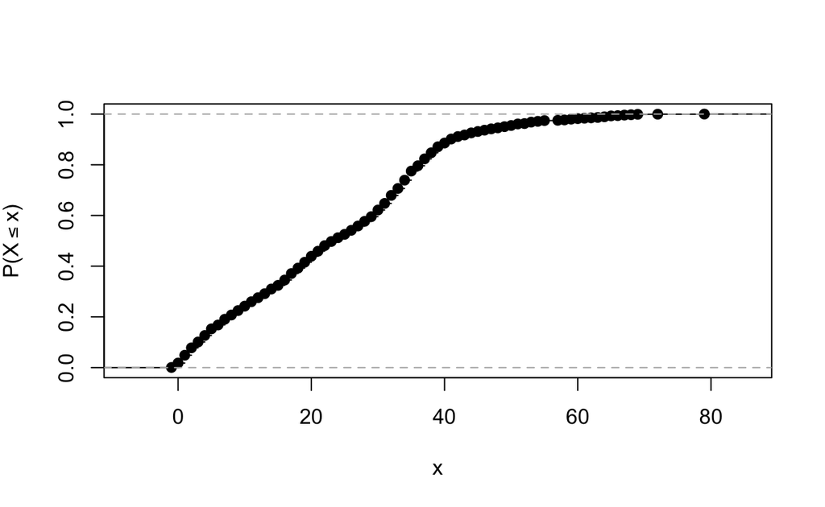

(#fig:age_CDF)Cumulative distribution function of the aircraft’s lifetime, denoted by $X$

We observe that more than 80% of the aircraft are between 0 and 40 years old at the time of the incident, with a small number of aircraft reaching nearly 80 years.

Next, we provide a scatter plot to visually inspect the association between age and damage level in (@ref(fig:damage_lifetime))

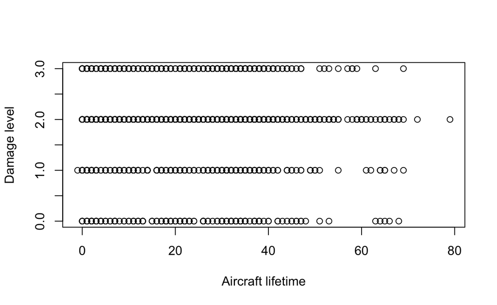

(#fig:damage_lifetime)Scatter plot of damage level (coded on a 0-3 scale) versus aircraft lifetime in recorded incidents

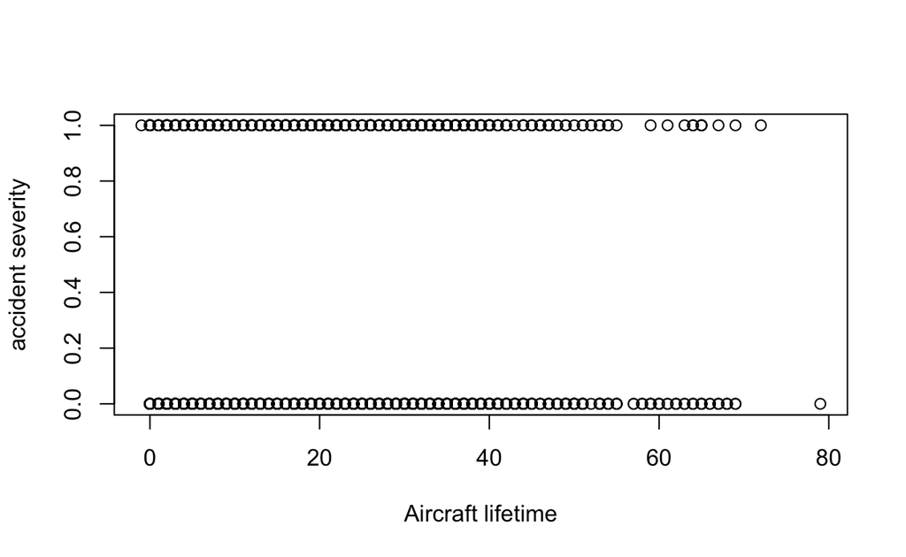

(#fig:damage_severity)Scatter plot of severity versus aircraft lifetime in recorded incidents

To investigate the marginal association between age and damage level we perform regression analysis using a linear model, logistic model in addition to quantile regression.

The fit diagnostic for the linear regression of damage level on lifetime of the plane gives

```
Call:
lm(formula = df.damage.age$damage_level ~ df.damage.age$lifetime)

Residuals:
    Min      1Q  Median      3Q     Max
-1.8694  0.1309  0.1334  0.1356  1.1392

Coefficients:
                         Estimate Std. Error t value Pr(>|t|)
(Intercept)             1.8693569  0.0341994  54.661   <2e-16 ***
df.damage.age$lifetime -0.0001235  0.0012004  -0.103    0.918
---
Signif. codes:  0 '***' 0.001 '**' 0.01 '*' 0.05 '.' 0.1 ' ' 1

Residual standard error: 0.7949 on 1884 degrees of freedom
Multiple R-squared:  5.621e-06, Adjusted R-squared:  -0.0005252
F-statistic: 0.01059 on 1 and 1884 DF,  p-value: 0.918
```

Here, we have coded the damage level on a scale of 0 to 3. Furthermore, the confidence interval is given by

```
                                beta        2.5 %      97.5 %
(Intercept)             1.8693568526  1.802284164 1.936429541
df.damage.age$lifetime -0.0001235299 -0.002477756 0.002230697
```

which is small and includes the null value of the slope.

Likewise, the logistic regression of aircraft lifetime on severity (with corresponding confidence intervals) is given below:

```
Call:
glm(formula = classification ~ lifetime, family = "binomial",
    data = df.damage.age)

Deviance Residuals:
    Min       1Q   Median       3Q      Max
-0.8589  -0.7911  -0.7661   1.5910   1.6827

Coefficients:
            Estimate Std. Error z value Pr(>|z|)
(Intercept) -1.13355    0.09886 -11.466   <2e-16 ***
lifetime     0.00413    0.00342   1.208    0.227
---
Signif. codes:  0 '***' 0.001 '**' 0.01 '*' 0.05 '.' 0.1 ' ' 1

(Dispersion parameter for binomial family taken to be 1)

    Null deviance: 2171.2  on 1885  degrees of freedom
Residual deviance: 2169.8  on 1884  degrees of freedom
AIC: 2173.8

Number of Fisher Scoring iterations: 4
```

```
(Intercept)    lifetime
   0.321890    1.004138
```

```
                  OR     2.5 %   97.5 %
(Intercept) 0.321890 0.2646635 0.390004
lifetime    1.004138 0.9974175 1.010886
```

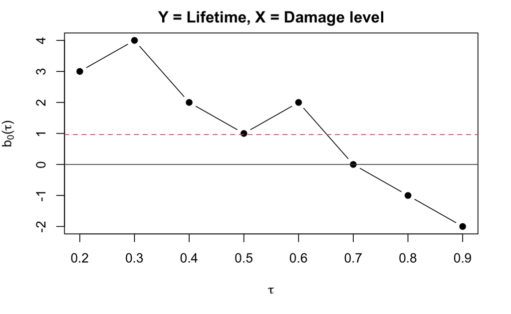

(#fig:quantile_lifetime)Quantile regression of damage level on the quantile of aircraft lifetime

The quantile plot shows that the conditional cumulative distribution function, conditioning on severity level ‘serious incident,’ is narrower compared to the conditional cumulative distribution function, conditioning on severity level ‘accident.’ In other words, both high and low quantiles are shifted towards the median.

As we did not find any strong associations between damage level and age of the aircraft marginally in the population. This motivated us to examine further whether such associations could exist within subsets of the population, such as the strata of incidents involving helicopters. Once again, we perform a logistic regression, which yields the following fit diagnostic and confidence intervals:

[output not shown]

```
(Intercept)    lifetime
   0.321890    1.004138
```

```
                  OR     2.5 %   97.5 %
(Intercept) 0.321890 0.2646635 0.390004
lifetime    1.004138 0.9974175 1.010886
```

## Conclusion

We employed linear, logistic and quantile regression to investigate the association between aircraft lifetime, accident severity and damage level, but did not find any statistically significant associations.